# Box-Muller Method

Nikolai German

2025-07-06

# 1 Introduction

The Box-Muller transformation is a method for generating pairs of independent standard normal random variables from uniform random variables. It uses the polar form of the normal distribution to transform two independent uniform random variables $U_1, U_2 \sim \text{Unif}(0,1)$ into two independent standard normal variables.

## 1.1 Mathematical Foundation

The transformation is based on: - $R = \sqrt{-2\ln(U_1)}$ - $\Theta = 2\pi U_2$

Then $X_1 = R\sin(\Theta)$ and $X_2 = R\cos(\Theta)$ are independent $\mathcal{N}(0,1)$ random variables.

# 2 Implementation

We implement a simple version of the Box-Muller method:

```r
box_muller <- function() {
  U <- runif(2)
  R <- -2 * log(U[[1]])
  Theta <- 2*pi*U[[2]]
  c(sqrt(R) * sin(Theta), sqrt(R) * cos(Theta))
}
```

# 3 Testing the Implementation

Let’s test our implementation and verify that it produces standard normal variates:

```r
set.seed(123)
X <- as.numeric(replicate(100, box_muller()))

# mean value
mean(X)
```

```
## [1] 0.00847973
```

```r
# variance
var(X)
```

```
## [1] 0.8727296
```

The results show that our implementation produces values with approximately zero mean and unit variance, as expected for standard normal variables.

# 4 Visualization

We compare the empirical density of our generated samples with the theoretical standard normal density:

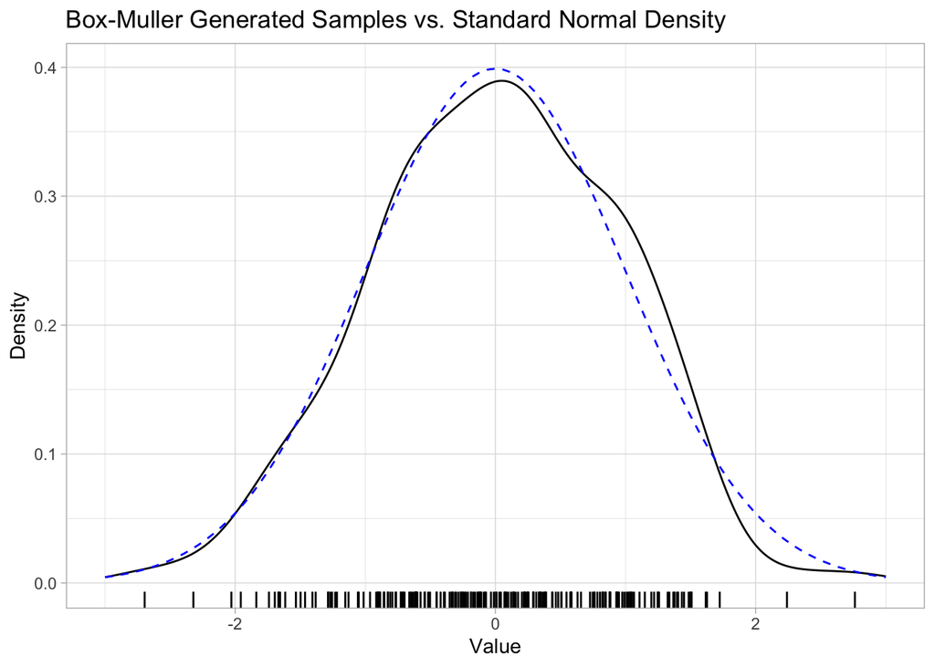

```r
library(ggplot2)

ggplot(as.data.frame(X), aes(X)) +
  geom_density() +
  geom_rug() +
  scale_x_continuous(limits = c(-3,3)) +
  stat_function(fun = dnorm, color = "blue", lty = "dashed") +
  labs(title = "Box-Muller Generated Samples vs. Standard Normal Density",
       x = "Value", y = "Density") +
  theme_light()
```

The plot demonstrates that our Box-Muller implementation successfully generates samples that closely follow the standard normal distribution (blue dashed line), confirming the effectiveness of this transformation method.